# Spatial Sampling Scenarios for Tanzania

Ernest Guevarra

07/01/2021

## Context

A study to be conducted in the northeastern border of Tanzania from Arusha up to west to Serengeti that will collect human population samples/information, livestock samples/information and also land use/land disturbance information. The question is what possible sampling approaches can be used that can unify these different sources of data for the study.

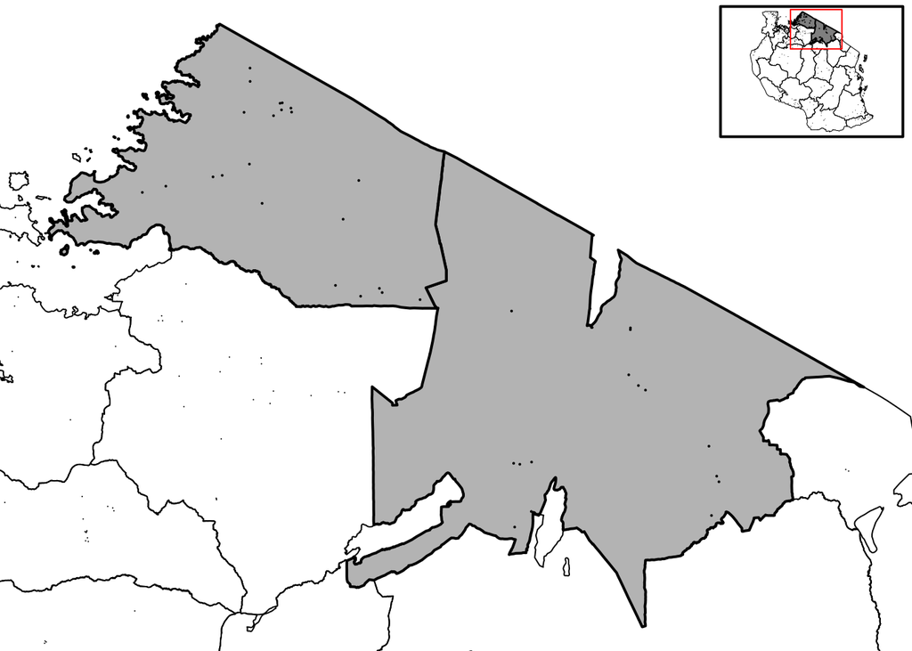

Northeastern border of Tanzania from Arusha to Serengeti

Other factors/conditions to consider are:

1. Population density of humans decrease as population density of livestock increase and as population density of humans increase, population density of livestock decrease.
2. In order to study land disturbance properly, samples/information need to also be collected in areas where humand and livestock do not reside/stay.

Additional assumptions made:

1. Approach to study sampling is using cluster sampling (CS) rather than simple random sampling (SRS).
2. Study will use the data perform general estimation of specific indicators but mostly to use the data and the indicators for modelling to address study questions.

This document provides some ideas/insights as to how sampling for a study can be done in the given context and the stated parameters and assumptions.

## Data and tools used for sampling scenario building

To build the sampling scenarios, the following datasets were retrieved and utilised:

1. Region, district, ward and village enumeration area boundaries datasets for Tanzania - the region, district and ward boundaries dataset were retrieved from the Tanzania Bureau of Statistics (www.nbs.go.tz). The village enumeration area boundaries dataset was retrieved from the Tanzania Bureau of Statistics years back but is not found in the bureau’s current website. This dataset includes population of each village enumeration area (based on 2002 census). These datasets were accessed via an R package called `tanzania` from the following Github repository (https://github.com/spatialworks/tanzania).
2. Boundaries map of livelihood zones of Tanzania - available from the Famine Early Warning Sytems Network or FEWS Net - https://fews.net/east-africa/tanzania/livelihood-zone-map/november-2009; This dataset is accessed via an R package called `tanzania` from the following Github repository (https://github.com/spatialworks/tanzania).
3. Raster map of ruminant livestock population - retrieved from the Gridded Livestock of the World (GLW) Database (https://dataverse.harvard.edu/dataverse/glw_3). This dataset is accessed via an R package called `tanzania` from the following Github repository (https://github.com/spatialworks/tanzania).
4. The package `spatialsampler` was used to perform grid-based sampling. The package is available via GitHub at https://github.com/spatialworks/spatialsampler
5. The package `smartr` was used to perform population proportional sampling (PPS). The package is available via GitHub at https://github.com/nutriverse/smartr

## Sampling scenarios

### Cluster sample selected proportional to population size

Using Tanzania census data for village enumeration areas within the study area, a selection of villages to sample proportional to their population sizes can be performed. Here we use the `smartr` package which has a function that can perform this selection given a list of villages with population sizes. Assuming that 30 clusters are needed for the study, the following operation can be performed:

```r
## Subset village to study areas
studyVillages <- village[village$REGNAME %in% c("Arusha", "Mara"), ]
studyVillagesSP <- data.frame(coordinates(studyVillages), studyVillages@data)
names(studyVillagesSP) <- c("x", "y", names(studyVillages@data))

studySamplePPS <- smartr::get_pps(df = studyVillagesSP, pop = "TOTAL", m = 30)
```

The following list of villages are selected using this approach:

| cluster_id | REGNAME | DISTNAME | WARD_NAME | STREET | TOTAL |
| --- | --- | --- | --- | --- | --- |
| 1 | Arusha | Monduli | Lolkisale | Lolkisale Part II | 3337 |
| 2 | Arusha | Monduli | Gelai Meirugoi | Meirugoi | 4107 |
| 3 | Arusha | Arumeru | Ngarenanyuki | Kisimiri juu | 2302 |
| 4 | Arusha | Arumeru | Makiba | Majengo | 4685 |
| 5 | Arusha | Arumeru | USA river | USA river | 13542 |
| 6 | Arusha | Arumeru | Moshono | Olkereiyan | 2983 |
| 7 | Arusha | Arumeru | Kiranyi | Kiranyi | 5675 |
| 8 | Arusha | Arumeru | Sokoni II | Ngiresi | 3172 |
| 9 | Arusha | Arumeru | Ilkiding’a | Ilkisongo | 2317 |
| 10 | Arusha | Arusha | Oloirien | Moivoi | 6897 |
| 11 | Arusha | Arusha | Sokon I | Sokoni I -Migungani | 3035 |
| 12 | Arusha | Arusha | Ngarenaro | Ngarenaro- Darajani | 2335 |
| 13 | Arusha | Karatu | Karatu | Karatu Mjini | 9437 |
| 14 | Arusha | Karatu | Mang’ola | Endamaghay | 3194 |
| 15 | Arusha | Karatu | Mbulumbulu | Kambi ya Simba | 4931 |
| 16 | Arusha | Ngorongoro | Nainokanoka | Alailelai | 6514 |
| 17 | Mara | Tarime | Mwema | Kubiterere | 3138 |
| 18 | Mara | Tarime | Nyamwaga | Nyamwaga | 4336 |
| 19 | Mara | Tarime | Binagi | Magoma | 3148 |
| 20 | Mara | Tarime | Bukwe | Buganjo | 3054 |
| 21 | Mara | Tarime | Kyang’ombe | Muhundwe | 1884 |
| 22 | Mara | Tarime | Bukura | Bubombi | 4102 |
| 23 | Mara | Tarime | Bumera | Turugeti | 1713 |
| 24 | Mara | Serengeti | Machochwe | Merenga | 2836 |
| 25 | Mara | Serengeti | Nyamoko | Masangura | 1239 |
| 26 | Mara | Musoma Rural | Buhemba | Kinyariri | 1800 |
| 27 | Mara | Musoma Rural | Buruma | Songora | 3778 |
| 28 | Mara | Musoma Rural | Mugango | Mbibi Jaasi | 822 |
| 29 | Mara | Musoma Rural | Murangi | Musanja | 4402 |
| 30 | Mara | Bunda | Salama | Salama Kati | 1566 |
| 31 | Mara | Bunda | Bunda | Bunda Mjini | 16332 |
| 32 | Mara | Bunda | Kibara | Nakatuba | 1862 |
| 33 | Mara | Musoma Urban | Mukendo | Mukendo | 1728 |
| 34 | Mara | Musoma Urban | Nyamatare | Mtongori | 962 |

And a map of these selected villages:

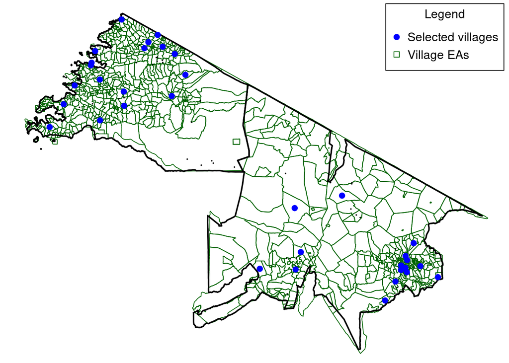

Selected sampling villages using population proportional sampling

```r
par(mar = c(0,0,0,0))

## Plot base maps
plot(studyArea, lty = 0)
plot(studyVillages, border = "darkgreen", add = TRUE)
plot(studyArea, lwd = 2, add = TRUE)

points(studySamplePPS[[2]][ , c("x", "y")], cex = 1, pch = 19, col = "blue")

legend("topright", inset = 0.01, box.lwd = 1,
       title = "Legend", cex = 1, y.intersp = 1.2,
       legend = c("Selected villages", "Village EAs"),
       pch = c(19, 0), col = c("blue", "darkgreen"), bty = "o")
```

- This will be a more traditional approach to sampling.
- Limitation will be that the resulting sample will be representative of human population but may not be of the livestock population given that areas with high population density will most likely have lesser livestock population.

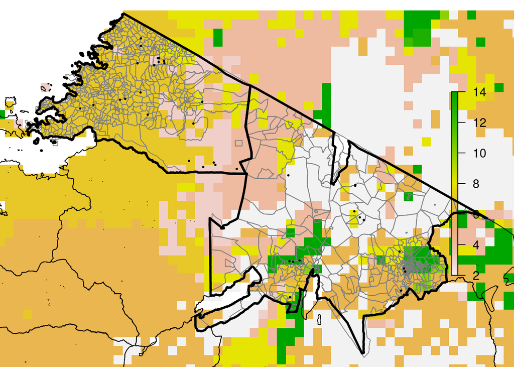

Ruminant population in the study area

```r
## Plot study area
par(mar = c(0,0,0,0))
plot(studyArea, lty = 0)
plot(ruminant_population, add = TRUE)
plot(studyVillages, lwd = 1, border = "gray50", add = TRUE)
plot(region, lwd = 1, add = TRUE)
plot(studyArea, lwd = 3, add = TRUE)
```

- This approach will also require that populations for each cluster are known to be able to select clusters proportionally.

### Spatial sampling

An alternative would be a spatial sample based on centric systematic area sampling (CSAS). The basic principle would be to create a sample that is evenly spread throughout the study area by applying a square grid across the study area. The clusters to sample are then selected by proximity to the centroids of the square grid. The following map illustrates this sampling approach on the study area assuming that $n = 30$ clusters are needed for the study.

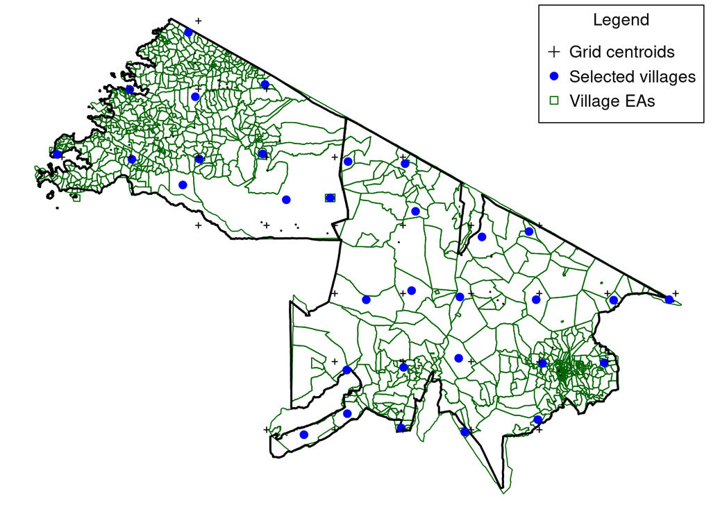

```r
par(mar = c(0,0,0,0))

## Plot base maps
plot(studyArea, lty = 0)
plot(studyVillages, border = "darkgreen", add = TRUE)
plot(studyArea, lwd = 2, add = TRUE)

## Create sampling grid (n = 30 square grids)
studySP <- create_sp_grid(x = studyArea,
                          n = 30,
                          country = "Tanzania",
                          buffer = 10, type = "csas")

## Get nearest point
studySampleVillages <- get_nearest_point(data = studyVillagesSP,
                                         data.x = "x", data.y = "y",
                                         query = studySP, n = 1)

points(studySampleVillages[ , c("x", "y")], cex = 1, pch = 19, col = "blue")
plot(studySP, cex = 0.5, add = TRUE)

legend("topright", inset = 0.01, box.lwd = 1,
       title = "Legend", cex = 1, y.intersp = 1.2,
       legend = c("Grid centroids", "Selected villages", "Village EAs"),
       pch = c(3, 19, 0), col = c("black", "blue", "darkgreen"), bty = "o")
```

Following is a list of the selected villages from the map.

| SPID | Region | District | Ward | Street | Population |
| --- | --- | --- | --- | --- | --- |
| 1 | Arusha | Karatu | Baray | Matala | 3252 |
| 2 | Arusha | Karatu | Baray | Dumbechand | 3057 |
| 3 | Arusha | Karatu | Buger | Guger | 3265 |
| 4 | Arusha | Monduli | Makuyuni | Makuyuni J.K.T Sec. | 364 |
| 5 | Arusha | Monduli | Lolkisale | Lolkisale Part II | 3337 |
| 6 | Arusha | Ngorongoro | Enduleni | Olpiro | 1088 |
| 7 | Arusha | Karatu | Qurus | Karatu Sec.&Lutheran Hospital | 706 |
| 8 | Arusha | Monduli | Selela | Selela | 3695 |
| 9 | Arusha | Arumeru | Musa | Likamba | 3648 |
| 10 | Arusha | Arumeru | King’ori | Mareu | 3320 |
| 11 | Arusha | Ngorongoro | Olbalbal | Meshili | 4446 |
| 12 | Arusha | Ngorongoro | Nainokanoka | Alailelai | 6514 |
| 13 | Arusha | Monduli | Engaruka | Engaruka Juu | 3864 |
| 14 | Arusha | Monduli | Kitumbeine | Kiserian | 1774 |
| 15 | Arusha | Monduli | Ol -molog | Elerai | 1293 |
| 16 | Arusha | Monduli | Ol -molog | Kamwanga | 3119 |
| 17 | Mara | Bunda | Hunyari | Kirawira camps | 160 |
| 18 | Mara | Serengeti | Ikoma | Seronera | 1335 |
| 19 | Mara | Serengeti | Ikoma | Lobo | 267 |
| 20 | Arusha | Ngorongoro | Sale | Sale | 2902 |
| 21 | Arusha | Monduli | Gelai Lumbwa | Alaililai | 2325 |
| 22 | Arusha | Monduli | Engarenaibor | Ngoswaki | 2069 |
| 23 | Mara | Musoma Rural | Bukumi | Busekera | 3797 |
| 24 | Mara | Bunda | Kabasa | Kung’ombe | 3012 |
| 25 | Mara | Bunda | Mugeta | Kyandege | 3445 |
| 26 | Mara | Serengeti | Manchira | Misseke | 2157 |
| 27 | Arusha | Ngorongoro | Soit Sambu | Soitsambu II | 1004 |
| 28 | Arusha | Ngorongoro | Orgosorok | Engusero Sambu | 5275 |
| 29 | Mara | Musoma Urban | Iringo | Iringo ‘A’ | 1836 |
| 30 | Mara | Musoma Rural | Buswahili | Wegero | 3067 |
| 31 | Mara | Tarime | Gorong’a | Masanga | 4711 |
| 32 | Mara | Tarime | Roche | Ng’ope | 2195 |

In this sample, we observe: